# Part_II_slide_deck_template slides

## Part II - Let's Invistigate the Prosper Loans world </br>

## by Siwar Sahraoui

**Investigation Overview**</br> In this investigation , I wanted to learn about the feature that affects the Prosper Score of each loan, so we will try to do some vizualsations in order to dicover features that affect this score

**Dataset Overview**</br> This set of data includes 113 937 loans with 81 characteristics for each loan , such as the amount of the loan, the interest rate, its current status, the borrower's income, and many others.

**Prosper Score distribution**</br> First of all , let's vizualise **how the ProsperScore are distribited in our Dataframe ?**

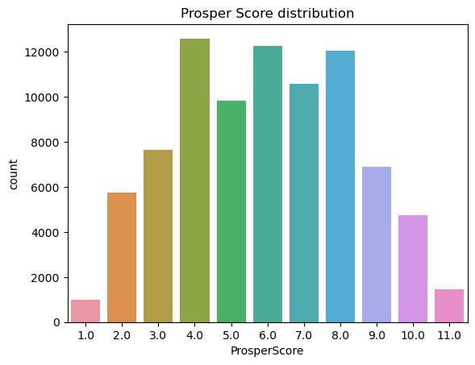

In our dataset the majority of rows have as a ProsperScore between 4.0 and 8.0

**Why does people need Prosper loans ?**</br> Let's vizualise the distrubtion of Listing categry so we will respond to the question why does people need loans ?

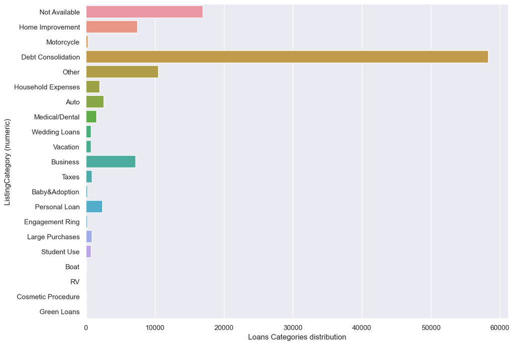

the Prosper loans are used mainly in Debt Consolidation

**Corrolation between numeric values**</br> we notice that the ProsperScore is affected with too many features , so to be sure of the numeric values that affect the prosperScore we will plot the Corrlation matrix

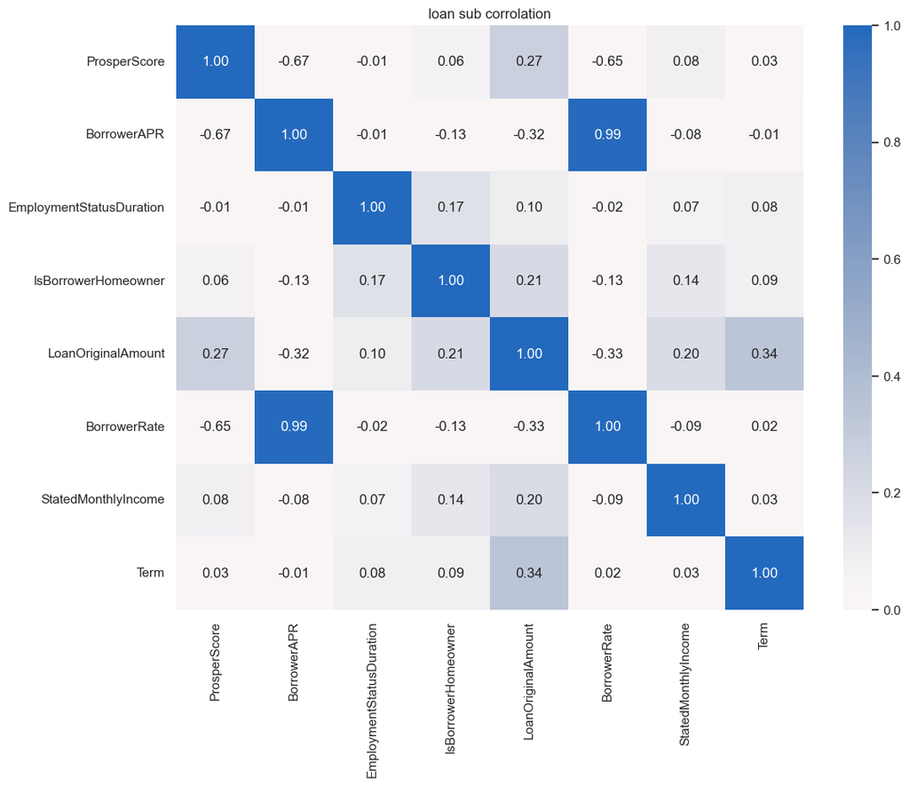